# A3: Incarceration

### Introduction

The over-policing of individuals of color is one of the most apparent examples of racism in the modern-day world, which directly leads into disproportionate levels of incarceration across the entirety of the U.S. In this report, I seek to mainly analyze the prison population rate per 100,000 people per county/state in the U.S. This is because I want to examine any trends in terms of how this rate might differ across different races, and how rates have increased/decreased over the recent years in general.

### Summary Information

In my research, the first thing I decided to focus on was the average black prison population rates and white prison population rates per 100,000 people across all the years in the dataset. I found that, on average, the prison population rate is **2785** for black people and **437** for white people, per 100,000 people across all counties/states in the U.S. I looked into calculating the ratio of black-to-white prison population rates using these numbers, which came out to roughly **6.37:1**, meaning that for each white person incarcerated in prison, there were roughly **six** black people incarcerated. This high ratio of black incarcerations points to a disparity in the level of policing between black and white people and points toward the level of racism present within our society.

Finally, I decided to look into the places with the highest black and white prison population rates in 2016 (since it was the most recent year in the dataset with a reliable amount of data). I found that the county with the highest black prison population rate in 2016 was **Madison County, NC** with a staggering rate of **38,461.54**, while the place with the highest white prison population rate was **McPherson County, NE** with a rate of **4,081.63**. Even honing in on a specific year, we can see that there is a large gap in the frequency in which black and white people are incarcerated into prison.

### The Dataset

The datasets used in this report originate from the [Vera Institute](https://github.com/vera-institute/incarceration-trends). The datasets were collected as part of a project that employed two Bureau of Justice Statistics data collections: the Census of Jails (conducted every 5-8 years since 1970) and the Annual Survey of Jails (conducted in non-census years since 1982). The data was collected as a means of analyzing trends in incarceration rates within the U.S. in the past few decades. Additionally, the collection of county-level data being used as opposed to only state-level data makes it easier to analyze these trends, as it is mainly county officials that decide how communities use incarceration.

[The first dataset (prison/jail population rate per 100,000 people per county/state)](https://github.com/melaniewalsh/Neat-Datasets/blob/main/us-prison-jail-rates.csv?raw=true) contains a total of 158,811 observations and 23 features.

[The second dataset (prison/jail population rate per 100,000 people per county/state since 1990)](https://raw.githubusercontent.com/melaniewalsh/Neat-Datasets/main/us-prison-jail-rates-1990.csv) contains a total of 91,031 observations and 23 features.

I think an important ethical question when working with data like thinking about how any potential bias was Identified and/or minimized when collecting the data. Another important question to consider might be if there are any potential common misinterpretations of the dataset, and how we could go about avoiding those misinterpretations.

Finally, a major limitation with the datasets might include the fact that some observations do not have data collected for certain features (for example, the total jail population rate for Autauga County, AL is missing for the year 1970). This might create some complications when searching for trends later if they are dependent on certain years’ data.

### Trends Over Time Chart

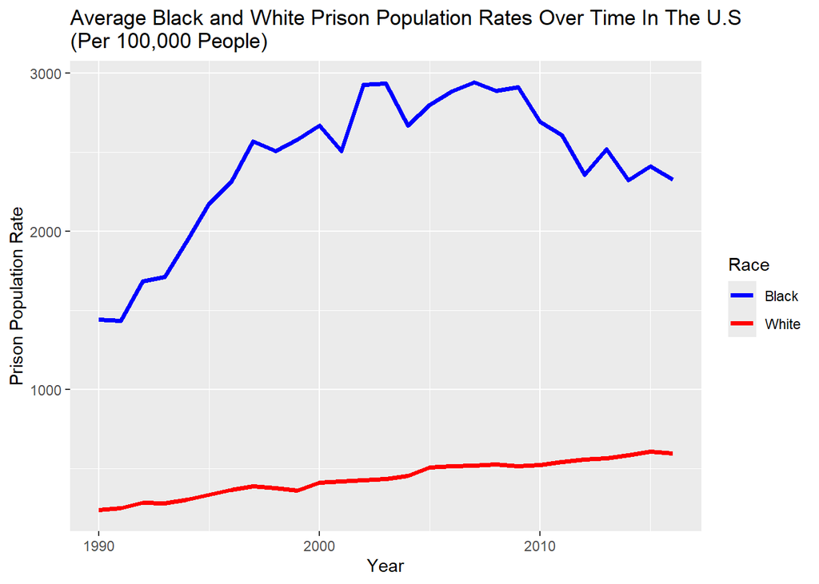

### Variable Comparison Chart

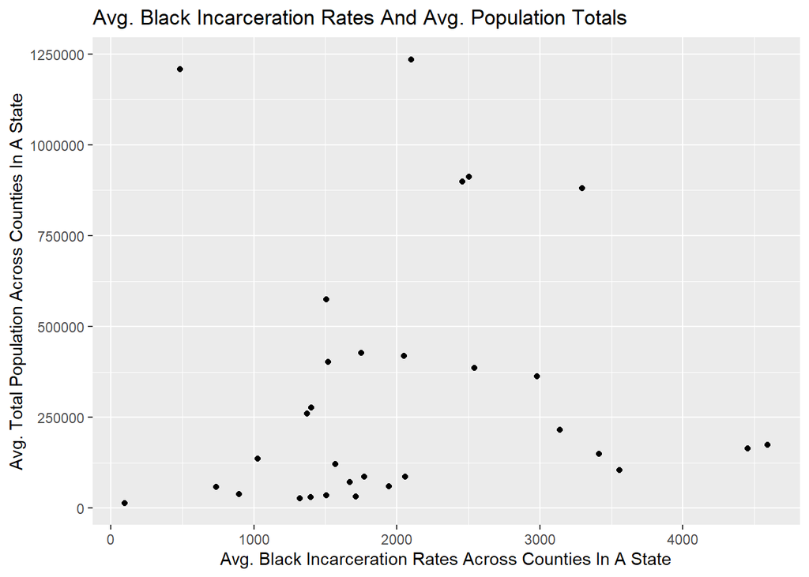

For my second chart, I wanted to examine if there were any correlations between the black prison incarceration rate within a county and the total population count of that county. Instead of going by individual counties, I decided to average over all counties in an individual state for both axes. I used a scatterplot for this, and found that there was a small concentration of rates of roughly 1000-2000 people in counties with an average population total less than 125,000. Also, there were some outliers; there was a state with an average county population of over 1,125,000 with a rate of black prison incarceration of less than 500. On the opposite end of the scale, there were states with average county populations of less than 250,000 with a black prison incarceration rate of over 4000.

### Map

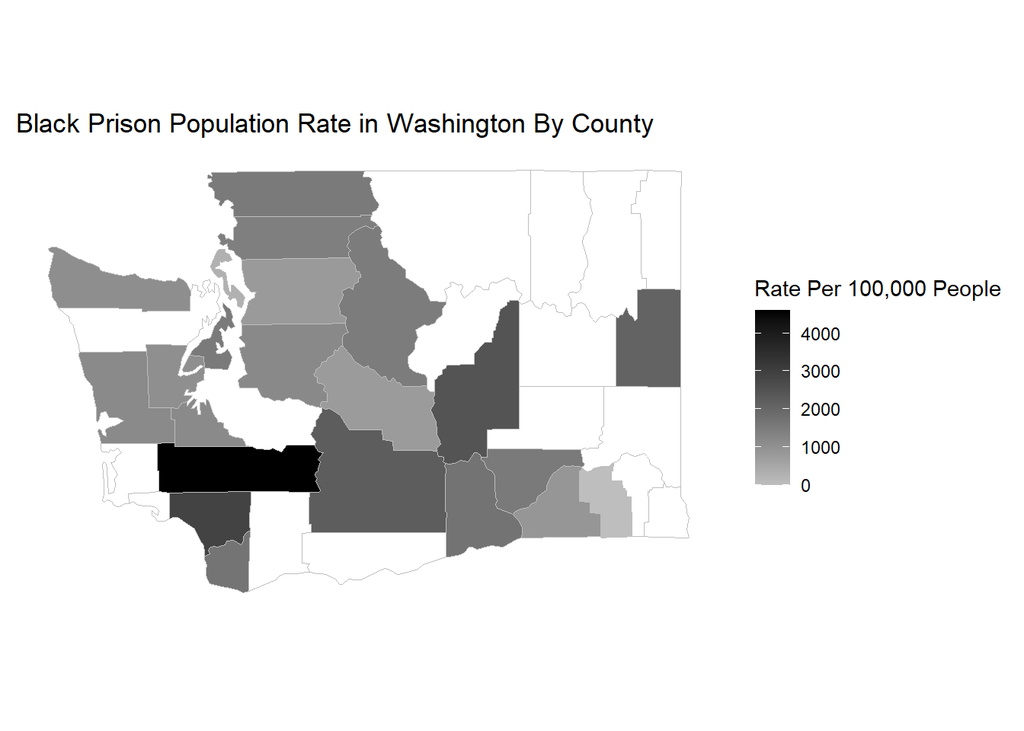

For my third chart, I decided to examine black prison incarceration rates, specifically in Washington. I focused in on the year 2016, as it was the most recent year with a reliable amount of data to use in my calculations. I wanted to examine if there were any major differences in the incarceration rates for individuals of color across different counties in Washington, and found that in 2016, Lewis County had a considerably higher incarceration rate for individuals of color compared to other counties in Washington (above 4000 per 100,000 people).